# MachineLearing - Traffic

Adnan Sevnic, Dustin Pacholleck

02 Juni, 2022

# Machine Learning Project - Traffic Data: Prep

## Data Preparation

### Overview

To get a good impression of the data we are working with it is crucial to get an overview of it.

| date_time | weather_general | weather_detailed | clouds_coverage_pct | temperature | rain_mm | snow_mm | traffic |
| --- | --- | --- | --- | --- | --- | --- | --- |
| 2014-10-01 00:00:00 | Clear | sky is clear | 1 | 11.5 | 0 | 0 | 508 |
| 2014-10-01 01:00:00 | Clear | sky is clear | 1 | 10.3 | 0 | 0 | 323 |
| 2014-10-01 02:00:00 | Clear | sky is clear | 1 | 8 | 0 | 0 | 274 |
| 2014-10-01 03:00:00 | Clear | sky is clear | 1 | 7.9 | 0 | 0 | 372 |
| 2014-10-01 04:00:00 | Clear | sky is clear | 1 | 6.4 | 0 | 0 | 812 |
| 2014-10-01 05:00:00 | Clear | sky is clear | 1 | 5.5 | 0 | 0 | 2720 |

Let’s have a closer look at summary statistics.

|  | date_time | weather_general | weather_detailed | clouds_coverage_pct | temperature | rain_mm | snow_mm | traffic |
| --- | --- | --- | --- | --- | --- | --- | --- | --- |
|  | Length:29701 | Length:29701 | Length:29701 | Min. : 0.00 | Length:29701 | Length:29701 | Length:29701 | Min. : 0 |
|  | Class :character | Class :character | Class :character | 1st Qu.: 1.00 | Class :character | Class :character | Class :character | 1st Qu.:1159 |
|  | Mode :character | Mode :character | Mode :character | Median : 64.00 | Mode :character | Mode :character | Mode :character | Median :3309 |
|  | NA | NA | NA | Mean : 50.21 | NA | NA | NA | Mean :3228 |
|  | NA | NA | NA | 3rd Qu.: 90.00 | NA | NA | NA | 3rd Qu.:4918 |
|  | NA | NA | NA | Max. :100.00 | NA | NA | NA | Max. :7263 |

As we can see, certain variables like temperature, etc. were loaded as characters but are in fact numeric. Also the date-time variable needs to be transformed.

After the transformation we once again have a look at the summary statistics:

|  | date_time | weather_general | weather_detailed | clouds_coverage_pct | temperature | rain_mm | snow_mm | traffic |
| --- | --- | --- | --- | --- | --- | --- | --- | --- |
|  | Min. :2014-10-01 00:00:00 | Clouds :10164 | sky is clear :8030 | Min. : 0.00 | Min. :-273.1 | Min. : 0.00 | Min. :0.0000000 | Min. : 0 |
|  | 1st Qu.:2015-07-03 04:15:00 | Clear : 8030 | mist :3491 | 1st Qu.: 1.00 | 1st Qu.: -1.3 | 1st Qu.: 0.00 | 1st Qu.:0.0000000 | 1st Qu.:1159 |
|  | Median :2016-05-31 05:30:00 | Rain : 3560 | overcast clouds :3491 | Median : 64.00 | Median : 8.3 | Median : 0.00 | Median :0.0000000 | Median :3309 |
|  | Mean :2016-11-04 19:24:26 | Mist : 3491 | broken clouds :3130 | Mean : 50.21 | Mean : 7.5 | Mean : 0.51 | Mean :0.0003609 | Mean :3228 |
|  | 3rd Qu.:2018-04-05 02:45:00 | Snow : 1794 | light rain :2248 | 3rd Qu.: 90.00 | 3rd Qu.: 18.3 | 3rd Qu.: 0.00 | 3rd Qu.:0.0000000 | 3rd Qu.:4918 |
|  | Max. :2018-12-31 23:00:00 | Drizzle: 920 | scattered clouds:2044 | Max. :100.00 | Max. : 35.1 | Max. :9831.30 | Max. :0.5100000 | Max. :7263 |
|  | NA’s :3 | (Other): 1742 | (Other) :7267 | NA | NA | NA | NA | NA |

As we can see, the data includes 3 missing variables which were not missing before the change of datatype for date-time. Therefore, we have to find out where the transformation caused an error and can correct it.

|  | date_time | weather_general | weather_detailed | clouds_coverage_pct | temperature | rain_mm | snow_mm | traffic |
| --- | --- | --- | --- | --- | --- | --- | --- | --- |
| 4649 | NA | Drizzle | light intensity drizzle | 90 | 5.3 | 0 | 0 | 610 |
| 4650 | NA | Rain | light rain | 90 | 5.3 | 0 | 0 | 611 |
| 13272 | NA | Clouds | few clouds | 20 | 2.6 | 0 | 0 | 580 |

### Date-Time

The variable date-time includes valuable further information which might help to train the models. Therefore, we are extracting from it year, month, day, hour and weekday. Afterwards, we inspect the newly formed variables.

|  | year | month | day | hour | weekday |
| --- | --- | --- | --- | --- | --- |
|  | 2014:2595 | 12 : 3333 | 04 : 1059 | 04 : 1299 | Dienstag :4112 |
|  | 2015:8566 | 07 : 3087 | 09 : 1059 | 08 : 1293 | Donnerstag:4239 |
|  | 2016:4795 | 11 : 2949 | 08 : 1042 | 06 : 1291 | Freitag :4234 |
|  | 2017:4423 | 05 : 2695 | 03 : 1041 | 10 : 1287 | Mittwoch :4302 |
|  | 2018:9322 | 10 : 2555 | 05 : 1023 | 23 : 1276 | Montag :4325 |
|  | NA | 08 : 2401 | 16 : 1016 | 07 : 1274 | Samstag :4182 |
|  | NA | (Other):12681 | (Other):23461 | (Other):21981 | Sonntag :4307 |

## Split Train dataset

For training and evaluating our models we will split the Train dataset into training and testing subsets.  
We split here the dataset not by time but randomly with a 70/30 fraction. Afterwards, we make sure that the data has similar properties.

### Visualize Traffic over Time

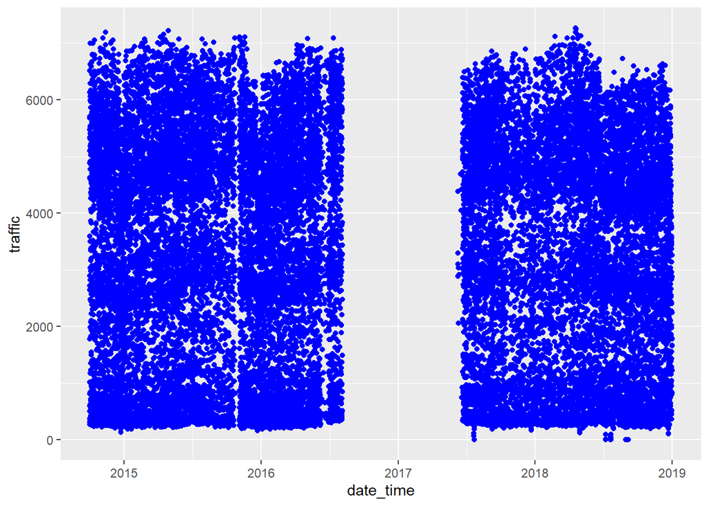

Since traffic seemingly does not have a time trend we can do a random split of 70/30.

### Split Data

```
## [1] "Training"
```

```
##    Min. 1st Qu.  Median    Mean 3rd Qu.    Max.
##       0    1159    3309    3229    4918    7263
```

```
## [1] "Testing"
```

```
##    Min. 1st Qu.  Median    Mean 3rd Qu.    Max.
##       0    1160    3310    3226    4918    7217
```

The summary statistics of the test and train subset are statistically similar.

## Data Exploration

Let us inspect the variables more in detail.

### Weather

#### General

| Var1 | Freq |
| --- | --- |
| Clear | 5613 |
| Clouds | 7101 |
| Drizzle | 660 |
| Fog | 345 |
| Haze | 518 |
| Mist | 2454 |
| Rain | 2500 |
| Smoke | 15 |
| Snow | 1232 |
| Squall | 2 |
| Thunderstorm | 353 |

#### Detailed

| Var1 | Freq |
| --- | --- |
| broken clouds | 2167 |
| drizzle | 234 |
| few clouds | 1061 |
| fog | 345 |
| freezing rain | 2 |
| haze | 518 |
| heavy intensity drizzle | 24 |
| heavy intensity rain | 210 |
| heavy snow | 407 |
| light intensity drizzle | 401 |
| light intensity shower rain | 8 |
| light rain | 1573 |
| light rain and snow | 2 |
| light shower snow | 3 |
| light snow | 710 |
| mist | 2454 |
| moderate rain | 673 |
| overcast clouds | 2440 |
| proximity shower rain | 21 |
| proximity thunderstorm | 215 |
| proximity thunderstorm with drizzle | 4 |
| proximity thunderstorm with rain | 14 |
| scattered clouds | 1433 |
| shower drizzle | 1 |
| shower snow | 0 |
| sky is clear | 5613 |
| sleet | 1 |
| smoke | 15 |
| snow | 109 |
| squalls | 2 |
| thunderstorm | 43 |
| thunderstorm with drizzle | 2 |
| thunderstorm with heavy rain | 33 |
| thunderstorm with light drizzle | 0 |
| thunderstorm with light rain | 26 |
| thunderstorm with rain | 16 |
| very heavy rain | 13 |

### Distibution of Traffic

#### Histogram of Traffic

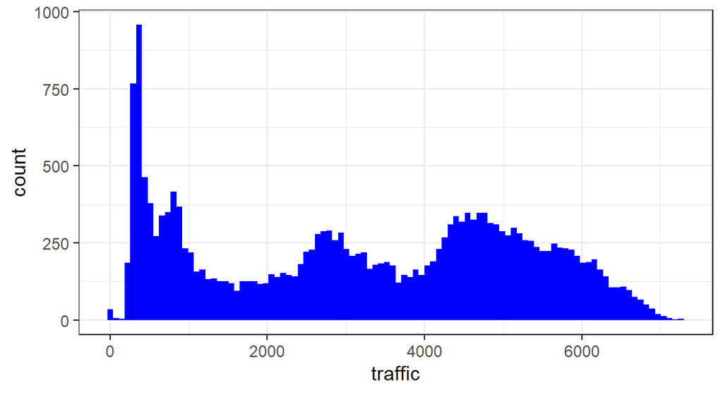

#### Histogram of Log of Traffic

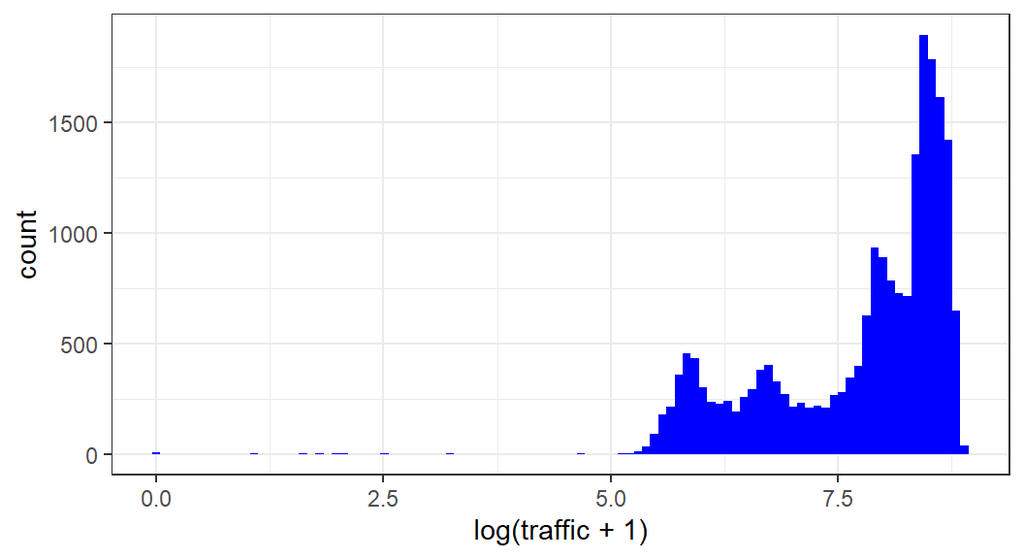

## Analyse Training Subset

### Check for Correlations of Numerical Variables

#### Table

|  | clouds_coverage_pct | temperature | rain_mm | snow_mm | traffic |
| --- | --- | --- | --- | --- | --- |
| clouds_coverage_pct | 1.0000000 | -0.1529462 | 0.0846773 | 0.0359405 | 0.0398753 |
| temperature | -0.1529462 | 1.0000000 | 0.0932793 | -0.0228258 | 0.1312682 |
| rain_mm | 0.0846773 | 0.0932793 | 1.0000000 | 0.0013735 | -0.0268412 |
| snow_mm | 0.0359405 | -0.0228258 | 0.0013735 | 1.0000000 | 0.0056950 |
| traffic | 0.0398753 | 0.1312682 | -0.0268412 | 0.0056950 | 1.0000000 |

#### CorrPlot

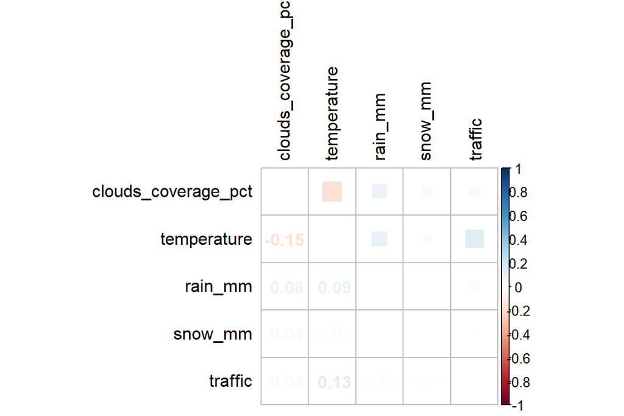

### Check for Correlations of Categorial Variables

|  | x |
| --- | --- |
| hour | 3055.450876 |
| weekday | 203.095977 |
| weather_general | 27.727276 |
| weather_detailed | 11.514484 |
| month | 10.507095 |
| year | 4.131435 |
| day | 2.262560 |

Here we can see that the highest F Values are for hour and weekday which means they might be important to include in our model. We also see that weather general is higher correlated with traffic then detailed. Besides that, it might be advantageous to not include year or month.

#### Visualisation

##### Traffic - Hour

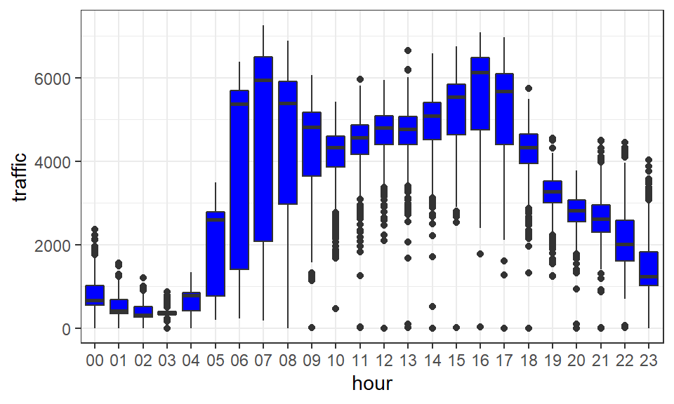

CramerV

```
## [1] 0.6431395
```

##### Traffic - Weekday

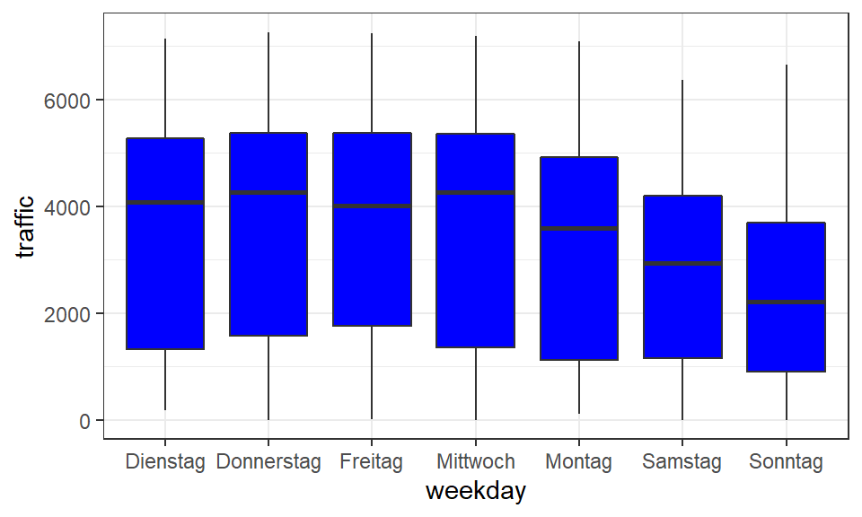

CramerV

```
## [1] 0.5687141
```

##### Traffic - Weather General

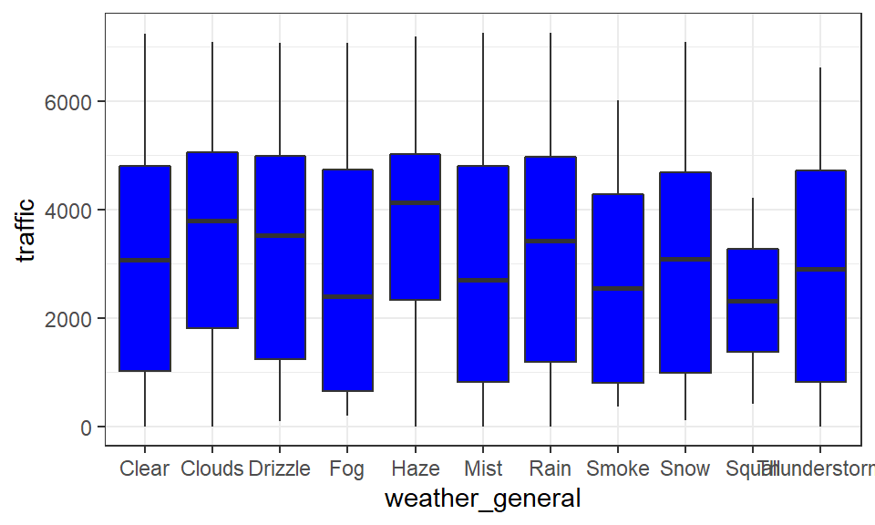

CramerV

```
## [1] 0.5273601
```

### (Near) Zero Variance

| variable | freqRatio | percentUnique | zeroVar | nzv |
| --- | --- | --- | --- | --- |
| snow_mm | 2305.666667 | 0.0577117 | FALSE | TRUE |
| rain_mm | 39.883721 | 1.5341702 | FALSE | TRUE |
| weather_detailed | 2.287286 | 0.1683259 | FALSE | FALSE |
| clouds_coverage_pct | 1.390204 | 0.2885586 | FALSE | FALSE |
| weather_general | 1.265099 | 0.0529024 | FALSE | FALSE |
| temperature | 1.165048 | 2.9240610 | FALSE | FALSE |
| year | 1.091487 | 0.0240466 | FALSE | FALSE |
| traffic | 1.086957 | 29.4377916 | FALSE | FALSE |
| month | 1.072165 | 0.0577117 | FALSE | FALSE |
| hour | 1.030939 | 0.1154235 | FALSE | FALSE |
| weekday | 1.016225 | 0.0336652 | FALSE | FALSE |
| day | 1.002618 | 0.1490886 | FALSE | FALSE |
| date_time | 1.000000 | 88.7510220 | FALSE | FALSE |

Here we can see that snow_mm and rain_mm are near zero variance variables. We might consider dropping them. Especially, since the correlation with traffic seems to be low and those variables are correlated with weather (snow or rain) and temperature.